# Importing libraries

```python
import numpy as np
import pandas as pd
import matplotlib.pyplot as plt
import seaborn as sns
```

# Loading the dataset

```python
df = pd.read_excel('data.xlsx')
df.head()
```

|  | Restaurant ID | Restaurant Name | Country Code | City | Address | Locality | Locality Verbose | Longitude | Latitude | Cuisines | Average Cost for two | Currency | Has Table booking | Has Online delivery | Price range | Aggregate rating | Rating color | Rating text | Votes |
| --- | --- | --- | --- | --- | --- | --- | --- | --- | --- | --- | --- | --- | --- | --- | --- | --- | --- | --- | --- |
| 0 | 7402935 | Skye | 94 | Jakarta | Menara BCA, Lantai 56, Jl. MH. Thamrin, Thamri... | Grand Indonesia Mall, Thamrin | Grand Indonesia Mall, Thamrin, Jakarta | 106.821999 | -6.196778 | Italian, Continental | 800000 | Indonesian Rupiah(IDR) | No | No | 3 | 4.1 | Green | Very Good | 1498 |
| 1 | 7410290 | Satoo - Hotel Shangri-La | 94 | Jakarta | Hotel Shangri-La, Jl. Jend. Sudirman | Hotel Shangri-La, Sudirman | Hotel Shangri-La, Sudirman, Jakarta | 106.818961 | -6.203292 | Asian, Indonesian, Western | 800000 | Indonesian Rupiah(IDR) | No | No | 3 | 4.6 | Dark Green | Excellent | 873 |
| 2 | 7420899 | Sushi Masa | 94 | Jakarta | Jl. Tuna Raya No. 5, Penjaringan | Penjaringan | Penjaringan, Jakarta | 106.800144 | -6.101298 | Sushi, Japanese | 500000 | Indonesian Rupiah(IDR) | No | No | 3 | 4.9 | Dark Green | Excellent | 605 |
| 3 | 7421967 | 3 Wise Monkeys | 94 | Jakarta | Jl. Suryo No. 26, Senopati, Jakarta | Senopati | Senopati, Jakarta | 106.813400 | -6.235241 | Japanese | 450000 | Indonesian Rupiah(IDR) | No | No | 3 | 4.2 | Green | Very Good | 395 |
| 4 | 7422489 | Avec Moi Restaurant and Bar | 94 | Jakarta | Gedung PIC, Jl. Teluk Betung 43, Thamrin, Jakarta | Thamrin | Thamrin, Jakarta | 106.821023 | -6.196270 | French, Western | 350000 | Indonesian Rupiah(IDR) | No | No | 3 | 4.3 | Green | Very Good | 243 |

```python
#Loading 2nd dataset
op = pd.read_excel("Country-Code.xlsx")
op.head ()
```

|  | Country Code | Country |
| --- | --- | --- |
| 0 | 1 | India |
| 1 | 14 | Australia |
| 2 | 30 | Brazil |
| 3 | 37 | Canada |
| 4 | 94 | Indonesia |

# LEFT JOIN

```python
#merging two datasets in one
df_rest = pd.merge(df,op,on='Country Code',how='left')
df_rest.head()
```

|  | Restaurant ID | Restaurant Name | Country Code | City | Address | Locality | Locality Verbose | Longitude | Latitude | Cuisines | Average Cost for two | Currency | Has Table booking | Has Online delivery | Price range | Aggregate rating | Rating color | Rating text | Votes | Country |
| --- | --- | --- | --- | --- | --- | --- | --- | --- | --- | --- | --- | --- | --- | --- | --- | --- | --- | --- | --- | --- |
| 0 | 7402935 | Skye | 94 | Jakarta | Menara BCA, Lantai 56, Jl. MH. Thamrin, Thamri... | Grand Indonesia Mall, Thamrin | Grand Indonesia Mall, Thamrin, Jakarta | 106.821999 | -6.196778 | Italian, Continental | 800000 | Indonesian Rupiah(IDR) | No | No | 3 | 4.1 | Green | Very Good | 1498 | Indonesia |
| 1 | 7410290 | Satoo - Hotel Shangri-La | 94 | Jakarta | Hotel Shangri-La, Jl. Jend. Sudirman | Hotel Shangri-La, Sudirman | Hotel Shangri-La, Sudirman, Jakarta | 106.818961 | -6.203292 | Asian, Indonesian, Western | 800000 | Indonesian Rupiah(IDR) | No | No | 3 | 4.6 | Dark Green | Excellent | 873 | Indonesia |
| 2 | 7420899 | Sushi Masa | 94 | Jakarta | Jl. Tuna Raya No. 5, Penjaringan | Penjaringan | Penjaringan, Jakarta | 106.800144 | -6.101298 | Sushi, Japanese | 500000 | Indonesian Rupiah(IDR) | No | No | 3 | 4.9 | Dark Green | Excellent | 605 | Indonesia |
| 3 | 7421967 | 3 Wise Monkeys | 94 | Jakarta | Jl. Suryo No. 26, Senopati, Jakarta | Senopati | Senopati, Jakarta | 106.813400 | -6.235241 | Japanese | 450000 | Indonesian Rupiah(IDR) | No | No | 3 | 4.2 | Green | Very Good | 395 | Indonesia |
| 4 | 7422489 | Avec Moi Restaurant and Bar | 94 | Jakarta | Gedung PIC, Jl. Teluk Betung 43, Thamrin, Jakarta | Thamrin | Thamrin, Jakarta | 106.821023 | -6.196270 | French, Western | 350000 | Indonesian Rupiah(IDR) | No | No | 3 | 4.3 | Green | Very Good | 243 | Indonesia |

```python
df_rest.columns = df_rest.columns.str.replace(' ','_')
df_rest.columns
```

```
Index(['Restaurant_ID', 'Restaurant_Name', 'Country_Code', 'City', 'Address',
       'Locality', 'Locality_Verbose', 'Longitude', 'Latitude', 'Cuisines',
       'Average_Cost_for_two', 'Currency', 'Has_Table_booking',
       'Has_Online_delivery', 'Price_range', 'Aggregate_rating',
       'Rating_color', 'Rating_text', 'Votes', 'Country'],
      dtype='object')
```

```python
#Check for null values
df_rest.isnull().sum()
```

```
Restaurant_ID           0
Restaurant_Name         1
Country_Code            0
City                    0
Address                 0
Locality                0
Locality_Verbose        0
Longitude               0
Latitude                0
Cuisines                9
Average_Cost_for_two    0
Currency                0
Has_Table_booking       0
Has_Online_delivery     0
Price_range             0
Aggregate_rating        0
Rating_color            0
Rating_text             0
Votes                   0
Country                 0
dtype: int64
```

# As Restaurant_name has null / missing value and check for what restraunt it belongs to

```python
df_rest[df_rest['Restaurant_Name'].isnull()]
```

|  | Restaurant_ID | Restaurant_Name | Country_Code | City | Address | Locality | Locality_Verbose | Longitude | Latitude | Cuisines | Average_Cost_for_two | Currency | Has_Table_booking | Has_Online_delivery | Price_range | Aggregate_rating | Rating_color | Rating_text | Votes | Country |
| --- | --- | --- | --- | --- | --- | --- | --- | --- | --- | --- | --- | --- | --- | --- | --- | --- | --- | --- | --- | --- |
| 1646 | 113702 | NaN | 1 | Ahmedabad | Opposite Sindhu Bhawan, Bodakdev, Ahmedabad | Bodakdev | Bodakdev, Ahmedabad | 72.501764 | 23.040163 | North Indian, Continental, Mexican, Italian | 800 | Indian Rupees(Rs.) | No | No | 3 | 4.1 | Green | Very Good | 769 | India |

# Since the restaurant name is missing, we dropped the record and reset the index.

```python
df_rest.dropna(axis=0,subset=['Restaurant_Name'],inplace=True)
df_rest.reset_index(drop=True,inplace=True)
```

```python
df_rest[df_rest['Cuisines'].isnull()]
```

|  | Restaurant_ID | Restaurant_Name | Country_Code | City | Address | Locality | Locality_Verbose | Longitude | Latitude | Cuisines | Average_Cost_for_two | Currency | Has_Table_booking | Has_Online_delivery | Price_range | Aggregate_rating | Rating_color | Rating_text | Votes | Country |
| --- | --- | --- | --- | --- | --- | --- | --- | --- | --- | --- | --- | --- | --- | --- | --- | --- | --- | --- | --- | --- |
| 9082 | 17374552 | Corkscrew Cafe | 216 | Gainesville | 51 W Main St, Dahlonega, GA 30533 | Dahlonega | Dahlonega, Gainesville | -83.985800 | 34.531800 | NaN | 40 | Dollar($) | No | No | 3 | 3.9 | Yellow | Good | 209 | United States |
| 9085 | 17501439 | Dovetail | 216 | Macon | 543 Cherry St, Macon, GA 31201 | Macon | Macon, Macon | -83.627979 | 32.836410 | NaN | 40 | Dollar($) | No | No | 3 | 3.8 | Yellow | Good | 102 | United States |
| 9093 | 17059060 | Hillstone | 216 | Orlando | 215 South Orlando Avenue, Winter Park, FL 32789 | Winter Park | Winter Park, Orlando | -81.365260 | 28.596682 | NaN | 40 | Dollar($) | No | No | 3 | 4.4 | Green | Very Good | 1158 | United States |
| 9405 | 17284158 | Jimmie's Hot Dogs | 216 | Albany | 204 S Jackson St, Albany, GA 31701 | Albany | Albany, Albany | -84.153400 | 31.575100 | NaN | 10 | Dollar($) | No | No | 1 | 3.9 | Yellow | Good | 160 | United States |
| 9493 | 17142698 | Leonard's Bakery | 216 | Rest of Hawaii | 933 Kapahulu Ave, Honolulu, HI 96816 | Kaimuki | Kaimuki, Rest of Hawaii | -157.813432 | 21.284586 | NaN | 10 | Dollar($) | No | No | 1 | 4.7 | Dark Green | Excellent | 707 | United States |
| 9503 | 17616465 | Tybee Island Social Club | 216 | Savannah | 1311 Butler Ave, Tybee Island, GA 31328 | Tybee Island | Tybee Island, Savannah | -80.848297 | 31.995810 | NaN | 10 | Dollar($) | No | No | 1 | 3.9 | Yellow | Good | 309 | United States |
| 9532 | 17284105 | Cookie Shoppe | 216 | Albany | 115 N Jackson St, Albany, GA 31701 | Albany | Albany, Albany | -84.154000 | 31.577200 | NaN | 0 | Dollar($) | No | No | 1 | 3.4 | Orange | Average | 34 | United States |
| 9534 | 17284211 | Pearly's Famous Country Cookng | 216 | Albany | 814 N Slappey Blvd, Albany, GA 31701 | Albany | Albany, Albany | -84.175900 | 31.588200 | NaN | 0 | Dollar($) | No | No | 1 | 3.4 | Orange | Average | 36 | United States |
| 9538 | 17606621 | HI Lite Bar & Lounge | 216 | Miller | 109 N Broadway Ave, Miller, SD 57362 | Miller | Miller, Miller | -98.989100 | 44.515800 | NaN | 0 | Dollar($) | No | No | 1 | 3.4 | Orange | Average | 11 | United States |

```python
#Since there were only 9 records without cuisines, we have replace the null values with Others.
df_rest['Cuisines'].fillna('Others',inplace=True)
```

```python
df_rest.isnull().sum()
df_rest.info()
```

```
<class 'pandas.core.frame.DataFrame'>
RangeIndex: 9550 entries, 0 to 9549
Data columns (total 20 columns):
 #   Column                Non-Null Count  Dtype
---  ------                --------------  -----
 0   Restaurant_ID         9550 non-null   int64
 1   Restaurant_Name       9550 non-null   object
 2   Country_Code          9550 non-null   int64
 3   City                  9550 non-null   object
 4   Address               9550 non-null   object
 5   Locality              9550 non-null   object
 6   Locality_Verbose      9550 non-null   object
 7   Longitude             9550 non-null   float64
 8   Latitude              9550 non-null   float64
 9   Cuisines              9550 non-null   object
 10  Average_Cost_for_two  9550 non-null   int64
 11  Currency              9550 non-null   object
 12  Has_Table_booking     9550 non-null   object
 13  Has_Online_delivery   9550 non-null   object
 14  Price_range           9550 non-null   int64
 15  Aggregate_rating      9550 non-null   float64
 16  Rating_color          9550 non-null   object
 17  Rating_text           9550 non-null   object
 18  Votes                 9550 non-null   int64
 19  Country               9550 non-null   object
dtypes: float64(3), int64(5), object(12)
memory usage: 1.5+ MB
```

# Explore the geographical distribution of the restaurants. Finding out the cities with maximum / minimum number of restaurants

```python
cntry_dist = df_rest.groupby(['Country_Code','Country']).agg( Count = ('Restaurant_ID','count'))
cntry_dist.sort_values(by='Count',ascending=False)
```

| Country_Code | Country | Count |
| --- | --- | --- |
| 1 | India | 8651 |
| 216 | United States | 434 |
| 215 | United Kingdom | 80 |
| 30 | Brazil | 60 |
| 189 | South Africa | 60 |
| 214 | UAE | 60 |
| 148 | New Zealand | 40 |
| 208 | Turkey | 34 |
| 14 | Australia | 24 |
| 162 | Phillipines | 22 |
| 94 | Indonesia | 21 |
| 166 | Qatar | 20 |
| 184 | Singapore | 20 |
| 191 | Sri Lanka | 20 |
| 37 | Canada | 4 |

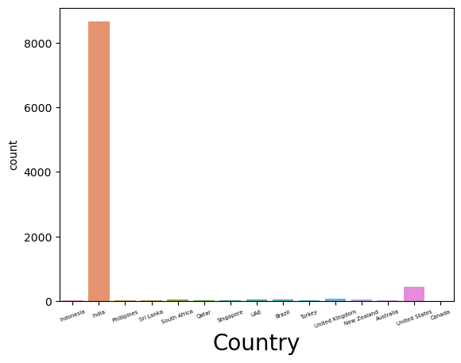

```python
# Create a countplot with country on the x-axis and count on the y-axis
sns.countplot(x="Country", data= df_rest)
plt.xticks(size=5)
plt.xticks(rotation=20)
plt.xlabel('Country', size=20)

# Show the plot
plt.show()
```

# We observe that India has then highest number of restaurants with 8651 restaurants and USA is number 2 with 434 restaurants

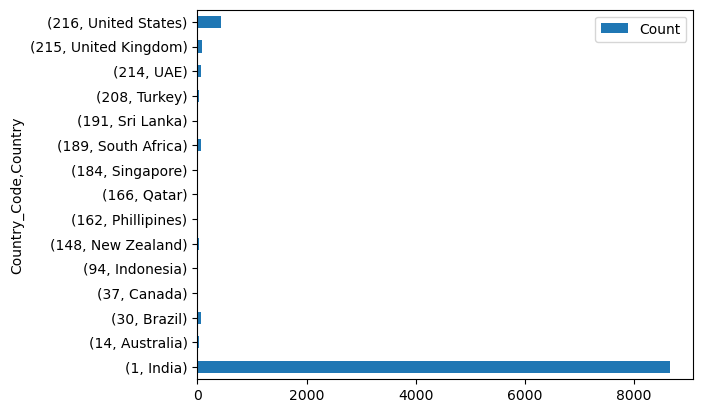

```python
cntry_dist.plot(kind='barh')
```

# Finding out cities having maximum and minimum number of restraunts.

```python
city_dist = df_rest.groupby(['Country','City']).agg(Count = ('Restaurant_ID','count'))
```

```python
city_dist.sort_values(by='Count',ascending=False)
```

| Country | City | Count |
| --- | --- | --- |
| India | New Delhi | 5473 |
|  | Gurgaon | 1118 |
|  | Noida | 1080 |
|  | Faridabad | 251 |
|  | Ghaziabad | 25 |
|  | ... | ... |
|  | Panchkula | 1 |
| Australia | Balingup | 1 |
| Indonesia | Bandung | 1 |
| Phillipines | Quezon City | 1 |
| United States | Winchester Bay | 1 |

141 rows × 1 columns

# We observe that New Delhi has maximum number of restraunts in the world followed by Gurgaon and Noida

# We also observe that multiple cities in multiple countries has only 1 restruant.

```python
min_cnt_rest = city_dist[city_dist['Count']==1]
min_cnt_rest.info()
min_cnt_rest
```

```
<class 'pandas.core.frame.DataFrame'>
MultiIndex: 46 entries, ('Australia', 'Armidale') to ('United States', 'Winchester Bay')
Data columns (total 1 columns):
 #   Column  Non-Null Count  Dtype
---  ------  --------------  -----
 0   Count   46 non-null     int64
dtypes: int64(1)
memory usage: 1.8+ KB
```

| Country | City | Count |
| --- | --- | --- |
| Australia | Armidale | 1 |
|  | Balingup | 1 |
|  | Beechworth | 1 |
|  | Dicky Beach | 1 |
|  | East Ballina | 1 |
|  | Flaxton | 1 |
|  | Forrest | 1 |
|  | Huskisson | 1 |
|  | Inverloch | 1 |
|  | Lakes Entrance | 1 |
|  | Lorn | 1 |
|  | Macedon | 1 |
|  | Mayfield | 1 |
|  | Middleton Beach | 1 |
|  | Montville | 1 |
|  | Palm Cove | 1 |
|  | Paynesville | 1 |
|  | Penola | 1 |
|  | Phillip Island | 1 |
|  | Tanunda | 1 |
|  | Trentham East | 1 |
|  | Victor Harbor | 1 |
| Canada | Chatham-Kent | 1 |
|  | Consort | 1 |
|  | Vineland Station | 1 |
|  | Yorkton | 1 |
| India | Mohali | 1 |
|  | Panchkula | 1 |
| Indonesia | Bandung | 1 |
| Phillipines | Quezon City | 1 |
|  | Tagaytay City | 1 |
| South Africa | Randburg | 1 |
| United States | Clatskanie | 1 |
|  | Cochrane | 1 |
|  | Fernley | 1 |
|  | Lakeview | 1 |
|  | Lincoln | 1 |
|  | Mc Millan | 1 |
|  | Miller | 1 |
|  | Monroe | 1 |
|  | Ojo Caliente | 1 |
|  | Potrero | 1 |
|  | Princeton | 1 |
|  | Vernonia | 1 |
|  | Weirton | 1 |
|  | Winchester Bay | 1 |

# Here we got to know that there are 46 cities in 7 different countries with 1 restaurants

```
C:\Users\Work Machine\AppData\Local\Temp\ipykernel_27444\283233139.py:1: FutureWarning: The default dtype for empty Series will be 'object' instead of 'float64' in a future version. Specify a dtype explicitly to silence this warning.
  restaurant_counts = pd.Series()
```

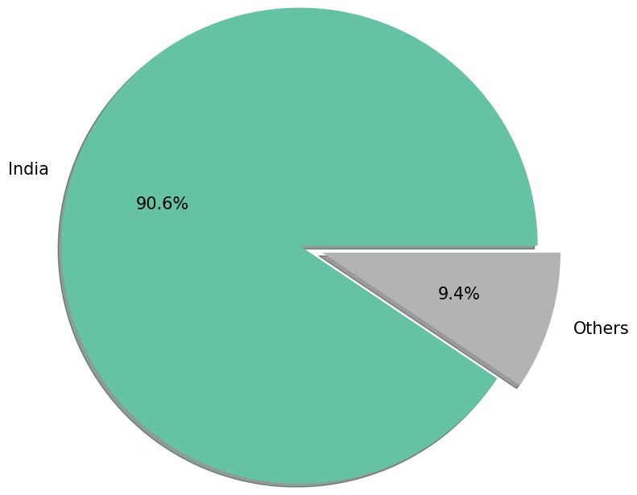

```python
restaurant_counts = pd.Series()
restaurant_counts['India'] = len(df_rest[df_rest.Country == 'India'])
restaurant_counts['Others'] = len(df_rest[df_rest.Country != 'India'])
restaurant_counts.plot.pie(radius = 2,autopct = '%1.1f%%' , textprops = {'size':15 }, explode
= [0.1,0.1], shadow = True, cmap ='Set2')
plt.xticks(size = 12, rotation = 10)
plt.ylabel('')
plt.show()
```

# From above Pi chart we can say that The country India alone has the 90.6% of total restaurants count and other 14 countries together holds only 9.4%

Analysing data from India should give us a pretty accurate representation of the entire data.

# Restaurant franchise is a thriving venture. So, it becomes very important to explore the franchise with most national presence.

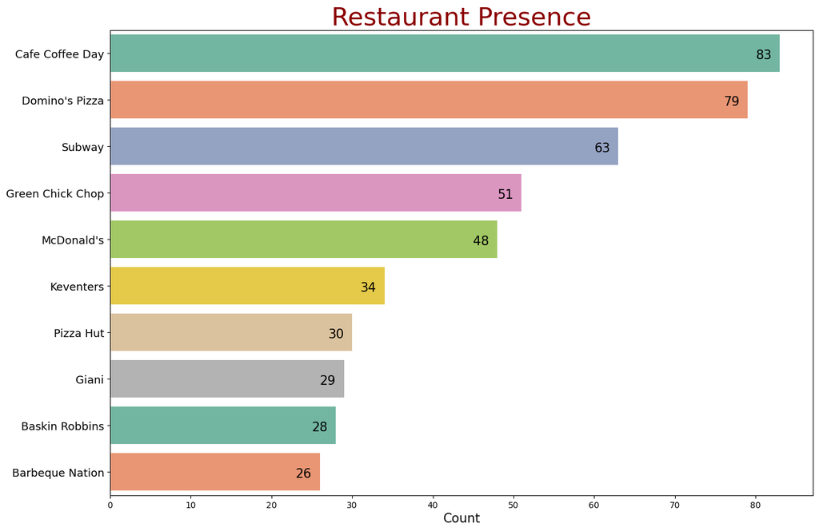

```python
plt.figure(figsize = (15,10))
vc=df_rest.Restaurant_Name.value_counts()[:10]
g = sns.barplot(y = vc.index, x = vc.values, palette = 'Set2')
g.set_yticklabels(g.get_yticklabels(),fontsize = 13)
for i in range(10):
 value = vc[i]
 g.text(x = value - 2,y = i +0.125 , s = value, color='black', ha="center",fontsize = 15)
g.set_xlabel('Count', fontsize = 15)
g.set_title('Restaurant Presence', fontsize = 30, color = 'darkred')
plt.show()
```

# cafe Coffe day has most national presesence

```python
df_rest1 = df_rest.copy()
df_rest1.columns
```

```
Index(['Restaurant_ID', 'Restaurant_Name', 'Country_Code', 'City', 'Address',
       'Locality', 'Locality_Verbose', 'Longitude', 'Latitude', 'Cuisines',
       'Average_Cost_for_two', 'Currency', 'Has_Table_booking',
       'Has_Online_delivery', 'Price_range', 'Aggregate_rating',
       'Rating_color', 'Rating_text', 'Votes', 'Country'],
      dtype='object')
```

```python
dummy = ['Has_Table_booking','Has_Online_delivery']
df_rest1 = pd.get_dummies(df_rest1,columns=dummy,drop_first=True)
df_rest1.head()
# 0 indicates 'NO'
# 1 indicates 'YES'
```

|  | Restaurant_ID | Restaurant_Name | Country_Code | City | Address | Locality | Locality_Verbose | Longitude | Latitude | Cuisines | Average_Cost_for_two | Currency | Price_range | Aggregate_rating | Rating_color | Rating_text | Votes | Country | Has_Table_booking_Yes | Has_Online_delivery_Yes |
| --- | --- | --- | --- | --- | --- | --- | --- | --- | --- | --- | --- | --- | --- | --- | --- | --- | --- | --- | --- | --- |
| 0 | 7402935 | Skye | 94 | Jakarta | Menara BCA, Lantai 56, Jl. MH. Thamrin, Thamri... | Grand Indonesia Mall, Thamrin | Grand Indonesia Mall, Thamrin, Jakarta | 106.821999 | -6.196778 | Italian, Continental | 800000 | Indonesian Rupiah(IDR) | 3 | 4.1 | Green | Very Good | 1498 | Indonesia | 0 | 0 |
| 1 | 7410290 | Satoo - Hotel Shangri-La | 94 | Jakarta | Hotel Shangri-La, Jl. Jend. Sudirman | Hotel Shangri-La, Sudirman | Hotel Shangri-La, Sudirman, Jakarta | 106.818961 | -6.203292 | Asian, Indonesian, Western | 800000 | Indonesian Rupiah(IDR) | 3 | 4.6 | Dark Green | Excellent | 873 | Indonesia | 0 | 0 |
| 2 | 7420899 | Sushi Masa | 94 | Jakarta | Jl. Tuna Raya No. 5, Penjaringan | Penjaringan | Penjaringan, Jakarta | 106.800144 | -6.101298 | Sushi, Japanese | 500000 | Indonesian Rupiah(IDR) | 3 | 4.9 | Dark Green | Excellent | 605 | Indonesia | 0 | 0 |
| 3 | 7421967 | 3 Wise Monkeys | 94 | Jakarta | Jl. Suryo No. 26, Senopati, Jakarta | Senopati | Senopati, Jakarta | 106.813400 | -6.235241 | Japanese | 450000 | Indonesian Rupiah(IDR) | 3 | 4.2 | Green | Very Good | 395 | Indonesia | 0 | 0 |
| 4 | 7422489 | Avec Moi Restaurant and Bar | 94 | Jakarta | Gedung PIC, Jl. Teluk Betung 43, Thamrin, Jakarta | Thamrin | Thamrin, Jakarta | 106.821023 | -6.196270 | French, Western | 350000 | Indonesian Rupiah(IDR) | 3 | 4.3 | Green | Very Good | 243 | Indonesia | 0 | 0 |

```python
df_rest1.columns
```

```
Index(['Restaurant_ID', 'Restaurant_Name', 'Country_Code', 'City', 'Address',
       'Locality', 'Locality_Verbose', 'Longitude', 'Latitude', 'Cuisines',
       'Average_Cost_for_two', 'Currency', 'Price_range', 'Aggregate_rating',
       'Rating_color', 'Rating_text', 'Votes', 'Country',
       'Has_Table_booking_Yes', 'Has_Online_delivery_Yes'],
      dtype='object')
```

# Ratio between restaurants allowing table booking and those which don't

```python
table_booking = df_rest1[df_rest1['Has_Table_booking_Yes']==1]['Restaurant_ID'].count()
table_nbooking =df_rest1[df_rest1['Has_Table_booking_Yes']==0]['Restaurant_ID'].count()
print('Ratio between restaurants that allow table booking vs. those that do not allow table booking: ',
      round((table_booking/table_nbooking),2))
```

```
Ratio between restaurants that allow table booking vs. those that do not allow table booking:  0.14
```

# Pie chart to show percentage of restaurants which allow table booking and those which don't

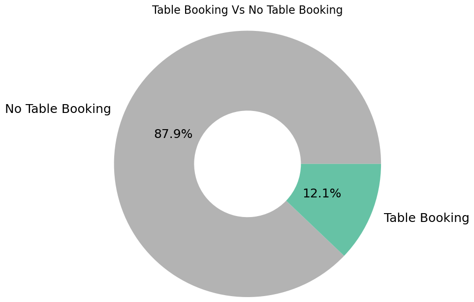

```python
axes = plt.subplots(figsize = (7,20))
labels ='No Table Booking', 'Table Booking'
df_rest1.Has_Table_booking_Yes.value_counts().plot.pie(ax = axes[1],labels=labels, autopct = '%0.1f%%', radius = 1.25,wedgeprops = {'width' : 0.75}, cmap = 'Set2_r',
textprops = {'size' : 18} )
axes[1].set_title('Table Booking Vs No Table Booking\n', fontsize = 16)
axes[1].set_ylabel('')


plt.show()
```